# Assignment 1

Author

tpha0822

Published

September 17, 2025

## Data Cleaning

Data cleaning process follows closely with the given Data Cleaning guide from The University of Sydney (DATA2x02 students 2025). After data is import from excel file, all columns name are cleaned for uses. A new working data-frame called “data” was created to prepare for future needs, not all columns inside of it were cleaned if they are not used in this research. The report has three question corresponding to its essentials columns which are all cleaned, including “target_grade”, “assignment_preference”, “weekly_study_hours”, “stall_choice” for our questions. Besides, “age” and “gender” were also cleaned for EDA, but only age was used.

**Library**

```r
library(tidyverse)
library(gendercoder)
library(janitor)
library(hms)
library(here)
library(dplyr)
library(gt)
library(knitr)
library(visdat)
library(readxl)
library(scales)
library(plotly)
theme_set(theme_bw())
```

**Import**

```r
raw = readxl::read_excel(here("D:/The_University_of_sydney/DATA2002/Assignment/survey.xlsx"))
```

**Clean columns’ name**

```r
old_names = colnames(raw)
new_names <- c(
  "timestamp",
  "target_grade",
  "assignment_preference",
  "trimester_or_semester",
  "age",
  "tendency_yes_or_no",
  "pay_rent",
  "stall_choice",
  "weetbix_count",
  "weekly_food_spend",
  "living_arrangements",
  "weekly_alcohol",
  "believe_in_aliens",
  "height",
  "commute",
  "daily_anxiety_frequency",
  "weekly_study_hours",
  "work_status",
  "social_media",
  "gender",
  "average_daily_sleep",
  "usual_bedtime",
  "sleep_schedule",
  "sibling_count",
  "allergy_count",
  "diet_style",
  "random_number",
  "favourite_number",
  "favourite_letter",
  "drivers_license",
  "relationship_status",
  "daily_short_video_time",
  "computer_os",
  "steak_preference",
  "dominant_hand",
  "enrolled_unit",
  "weekly_exercise_hours",
  "weekly_paid_work_hours",
  "assignments_on_time",
  "used_r_before",
  "team_role_type",
  "university_year",
  "favourite_anime",
  "fluent_languages",
  "readable_languages",
  "country_of_birth",
  "wam",
  "shoe_size",
  "books_read_highschool",
  "daily_water_intake_l",
  "perceived_old_age",
  "study_music_preference"
)
# overwrite the old names with the new names:
colnames(raw) = new_names
# combine old and new into a data frame:
name_combo = bind_cols(New = new_names, Old = old_names)
name_combo |> gt::gt()
```

| New | Old |
| --- | --- |
| timestamp | Timestamp |
| target_grade | What final grade are you aiming to achieve in DATA2x02? |
| assignment_preference | When it comes to assignments / due tasks do you: |
| trimester_or_semester | Would you prefer to have a trimester system (3 main teaching sessions per year) or stick with the existing semester system (2 main teaching sessions per year)? |
| age | How old are you? |
| tendency_yes_or_no | Do you tend to lean towards saying "yes" or towards saying "no" to things throughout life? |
| pay_rent | Do you pay rent? |
| stall_choice | You enter a public bathroom and there are three stalls to choose from. All three are unoccupied. Which do you choose? |
| weetbix_count | How many Weet-Bix would you typically eat in one sitting? |
| weekly_food_spend | What is the average amount of money you spend each week on food/beverages? |
| living_arrangements | What are your current living arrangements? |
| weekly_alcohol | How much alcohol do you consume each week? |
| believe_in_aliens | Do you believe in the existence of aliens (Extraterrestrial Life)? |
| height | How tall are you? |
| commute | How do you get to university? |
| daily_anxiety_frequency | How often would you say you feel anxious on a daily basis? |
| weekly_study_hours | How many hours a week do you spend studying? |
| work_status | Do you work? |
| social_media | What is your favourite social media platform? |
| gender | What is your gender? |
| average_daily_sleep | How much sleep do you get (on avg, per day)? |
| usual_bedtime | What time do you usually go to bed? |
| sleep_schedule | How consistent would you rate your sleep schedule? |
| sibling_count | How many siblings do you have? |
| allergy_count | How many allergies do you know you have? |
| diet_style | What is your diet style? |
| random_number | Pick a number at random between 1 and 10 (inclusive) |
| favourite_number | What is your favourite number (between 1 and 10 inclusive) |
| favourite_letter | What is your favourite letter from the English alphabet? |
| drivers_license | Do you have a driver's license? |
| relationship_status | Do you currently have a partner? |
| daily_short_video_time | How much time do you spend on short video apps (like tiktok or reels) every day? |
| computer_os | What computer OS (operating system) are you currently using? |
| steak_preference | How do you like your steak cooked? |
| dominant_hand | What is your dominant hand? |
| enrolled_unit | Which unit are you enrolled in? |
| weekly_exercise_hours | On average, how many hours each week do you spend exercising? |
| weekly_paid_work_hours | How many hours a week (on average) do you work in paid employment? |
| assignments_on_time | Do you submit assignments on time? |
| used_r_before | Have you ever used R before starting DATA2x02? |
| team_role_type | What kind of role (active or passive) do you think you are when working as part of a team? |
| university_year | Which year of university are you currently in? |
| favourite_anime | What is your favourite anime? |
| fluent_languages | How many languages can you speak fluently? |
| readable_languages | How many languages can you read? |
| country_of_birth | What country were you born in? |
| wam | What is your WAM (weighted average mark)? |
| shoe_size | What is your shoe size? |
| books_read_highschool | How many books did you read in high school? (ages 12-18) |
| daily_water_intake_l | How many litres of water do you drink on average per day? |
| perceived_old_age | What age do you think is "old"? |
| study_music_preference | What kind of music do you listen to when you study? |

**Create a clean data set for future work**

- Age column was cleaned by setting any bad values such as N/A or “unserious” value was turned into average age.
- Gender was to Male (set as M), Female (set as F), and Others.
- For data varaible which was used for question 1 and 2, all null value will be deleted which include “target_grade, assignment_preference, weekly_study_hours”.
- For question 3, stall_choice was turned into a “factor” data type, then I create a table assigned to a variable called “stalled” with 3 levels “first”, “middle”, “last” representing 3 choices. Then I got rid of the column N/A since the created table included N/A because it was not cleaned in the “raw” data variable.

```r
# Create cleaned dataset
data <- raw[, c("target_grade", "assignment_preference", "age", "gender", "university_year", "enrolled_unit", "weekly_study_hours", "work_status", "weekly_paid_work_hours", "average_daily_sleep", "usual_bedtime", "weekly_exercise_hours", "weekly_food_spend", "wam")]
data = data %>%
  #For any row that is totally empty, drop it.
  remove_empty(c("rows", "cols"))

#For every "troll" data, just convert into NA value
data$age <- ifelse(data$age > 50 | is.na(data$age) | data$age < 10, as.integer(mean(data$age, na.rm=TRUE)), data$age)
data$age <- as.integer(data$age)

data$target_grade <- ifelse(data$target_grade == "Fail", NA, data$target_grade)

#Gender cleaning
data$gender <- ifelse(data$gender %in% c("NVIDIA RTX5090", "armored helicopter", "gender is a scam created by bathroom companies to sell more bathrooms. [female]", "helicopter", "assasin"), NA, data$gender)
data$gender <- ifelse(data$gender == "As in social role ? Male", "male", data$gender)
data$gender <- toupper(data$gender)
data$gender[data$gender %in% c("FEMALE", "F", "GIRL", "FEMAL", "FAMALE")] <- "F"
data$gender[data$gender %in% c("MALE", "M", "MALE ♂", "MAN", "BLOKE")] <- "M"
data$gender <- ifelse(data$gender %in% c("N/A", "HUMAN"), NA, data$gender)
data$gender[!data$gender %in% c("F", "M", NA)] <- "Others"

data = data %>% drop_na(target_grade, assignment_preference, weekly_study_hours)
raw$stall_choice = as.factor(raw$stall_choice)
stall = raw$stall_choice
choice = c("first", "middle", "last")
levels(stall) = choice
stall = stall[!is.na(stall)]
```

## Exploratory Data Analysis

- Before we start the investigation, let’s first have a look at our survey data, the columns from raw data have already been cleaned in advance to looks nicer. The below information would be the summary of our data.

```r
#summary(raw)
head(raw, 3) %>%
  gt() %>%
  tab_header(title = "First 5 Rows of Survey Data") %>%
  tab_options(table.font.size = 10)
```

| timestamp | target_grade | assignment_preference | trimester_or_semester | age | tendency_yes_or_no | pay_rent | stall_choice | weetbix_count | weekly_food_spend | living_arrangements | weekly_alcohol | believe_in_aliens | height | commute | daily_anxiety_frequency | weekly_study_hours | work_status | social_media | gender | average_daily_sleep | usual_bedtime | sleep_schedule | sibling_count | allergy_count | diet_style | random_number | favourite_number | favourite_letter | drivers_license | … |
| --- | --- | --- | --- | --- | --- | --- | --- | --- | --- | --- | --- | --- | --- | --- | --- | --- | --- | --- | --- | --- | --- | --- | --- | --- | --- | --- | --- | --- | --- | --- |
| 2025-08-22 10:37:24.263 | Distinction | draw up a schedule and work through it in planned stages | Semester | 23 | More "Yes" | No | B: Middle | 2 | 35 | With parent(s) and/or sibling(s) | Less than 5 standard drinks | Yes | 160.0 | Train, Walk | 6 | 21 | Part time | Pinterst | Female | 7.0 | 1899-12-31 23:30:00 | 7 | 1.0 | 1.0 | Omnivorous | 3 | 3 | k | Yes | … |
| 2025-08-22 10:37:56.071 | Distinction | draw up a schedule and work through it in planned stages | Semester | 19 | More "Yes" | Yes | B: Middle | NA | 200 | Alone | I don't drink alcohol | Yes | 178cm | Walk | 9 | 35 | I don't currently work | tiktok | male | 8 hours | 1899-12-31 22:30:00 | 5 | 1.0 | 2.0 | Vegetarian | 5 | 5 | A | Yes | … |
| 2025-08-22 10:38:52.519 | High Distinction | draw up a schedule and work through it in planned stages | Semester | 20 | More "Yes" | No | B: Middle | NA | 100 | With parent(s) and/or sibling(s) | I don't drink alcohol | No | 1.75m | Train, Walk | 8 | 30 | Casual | NA | male | 6-7 | 1899-12-31 | 8 | 0.0 | 1.0 | Omnivorous | 6 | 7 | z | Yes | … |

What about missing data?

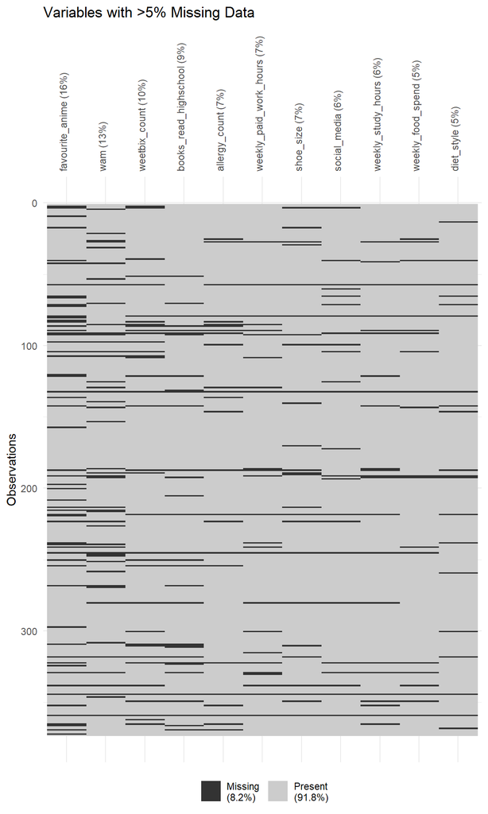

The data-set itself has myriads of trouble let alone null values, for example, in column “age”, some answer in the survey is “unreal” because not all answer is seriously “answered”. These answers from age will later be converted into the “mean” of age column, including NA value. All cleaned data and value will be saved into a new data-=frame called data. Let’s have a look at the distinct age value we currently have!

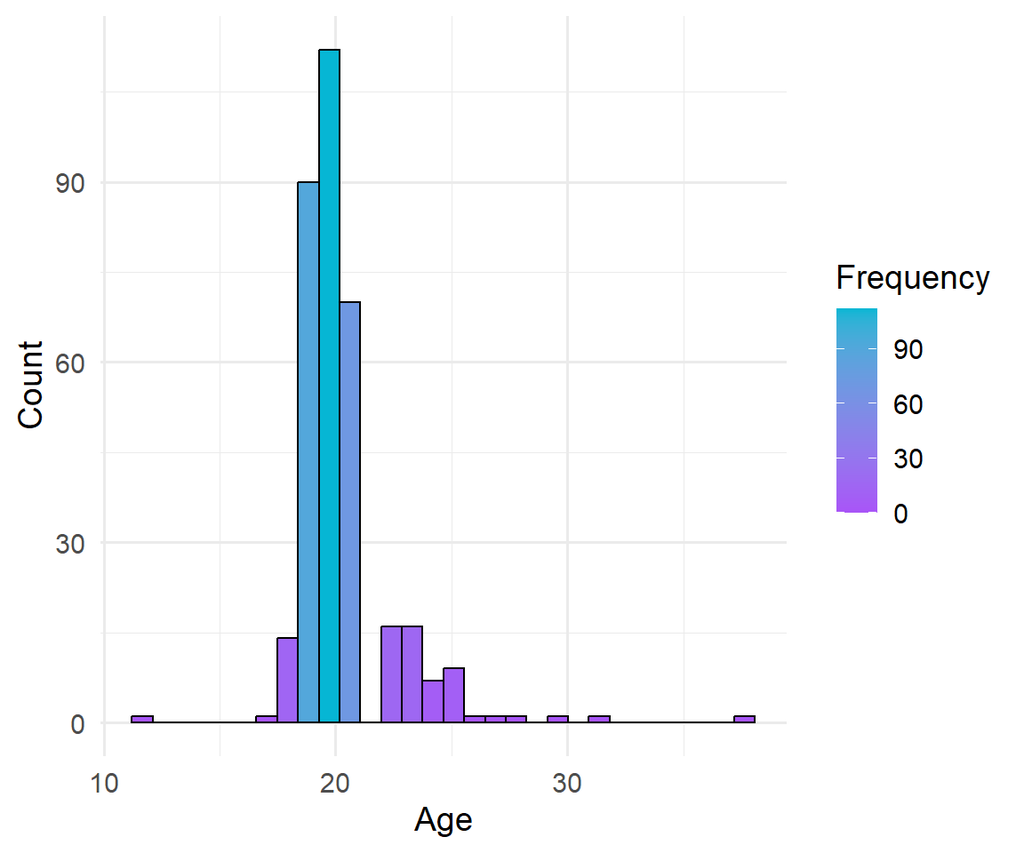

Having said that, the aim of this report will be placed on performing hypothesis tests to uncover the truth from the samples survey, it does not represent the real-world situation, but at the same time it is still worth looking at. Let’s begin our testing to answer the big question.

## Conducting research

### Setting seed for our research

In this report, we will use seed 10 for reproducible result later!

```r
set.seed(10)
```

### Research 1: Are students who “cram at the last second” less likely to aim for High Distinction?

#### Hypothesis

$$\begin{align*}
&H_0 \text{: there is no association between study approach and targeted grade} \\
&H_1: \text{ Students who cram at the end are less likely to aim for High Distinction than students who opt for other approach} \\
\end{align*}$$

#### Assumptions

- The result of the survey is randomly sampled. This is true since the survey comes from student in DATA2x02 cohort.
- Our expected observations are not too small (expected value greater than 5).
- a = 0.05

#### Checking assumptions

- The result of the survey is randomly sample because it was sampled from student in DATA2x02 cohort.
- Let’s check if expected frequency is over 5 for all. (In the dataset, there were some answers grade target “Fail”, I assume these are not serious answer, so all “Fail” answers are ignored in this report, we would only regard target from Pass to High Distinction, of course null values are all dropped in both of our parameters!

```r
tab <- table(data$target_grade, data$assignment_preference)
colnames(tab) = c("Cram", "Immediately", "Scheduled")
rownames(tab) = c("C", "D", "HD", "P")
tab = addmargins(tab)
```

```r
observed <- matrix(c(9, 7, 15,
                     26, 21, 52,
                     35, 55, 100,
                     5, 1, 6),
                   nrow = 4, byrow = TRUE)
# Calculate row totals
row_totals <- rowSums(observed)
# Calculate column totals
col_totals <- colSums(observed)

# Calculate grand total
grand_total <- sum(observed)

# Calculate expected values using formula: (row total × column total) / grand total
expected <- outer(row_totals, col_totals) / grand_total
rownames(expected) <- rownames(observed)
colnames(expected) <- colnames(observed)

print("Expected Frequencies:")
```

```
[1] "Expected Frequencies:"
```

```r
rownames(observed) <- c("C", "D", "HD", "P")
colnames(observed) <- c("Cram", "Immediately", "Scheduled")
rownames(expected) <- c("C", "D", "HD", "P")
colnames(expected) <- c("Cram", "Immediately", "Scheduled")
```

For cases like people who would like to Cram at the last minutes and try to aim for Pass, the expected frequency is less than 5, violating what the assumption of “Chi-square test for independence”. Which means we must find alternatives test that can fit with smaller values such as Fisher’s exact test. But Fisher’s exact test only applies for 2x2 contingency tables. Then we can aim for Monte Carlo test with random seed already being set.

```r
monte_carlo_chi_square <- function(observed, n_simulations = 10000) {
  # Calculate observed chi-square
  row_totals <- rowSums(observed)
  col_totals <- colSums(observed)
  grand_total <- sum(observed)
  expected <- outer(row_totals, col_totals) / grand_total

  chi_squared_obs <- sum((observed - expected)^2 / expected)

  # Vector to store simulated chi-square statistics
  chi_squared_sim <- numeric(n_simulations)

  # Run simulation
  for (i in 1:n_simulations) {
    # Generate random table with same marginal totals
    sim_table <- r2dtable(1, row_totals, col_totals)[[1]]
    sim_table <- matrix(sim_table, nrow = length(row_totals))

    # Calculate chi-square for simulated table
    chi_squared_sim[i] <- sum((sim_table - expected)^2 / expected)

  }

  # Calculate p-value
  p_value <- mean(chi_squared_sim >= chi_squared_obs)

  return(list(
    observed_chi_sq = chi_squared_obs,
    simulated_chi_sq = chi_squared_sim,
    p_value = p_value,
    n_simulations = n_simulations,
    expected = expected
  ))
}

# Run Monte Carlo simulation with YOUR data
mc_results <- monte_carlo_chi_square(observed, n_simulations = 10000)
```

Let’s have a look at our observed test statistics and see where it’s located when we simulate the test!

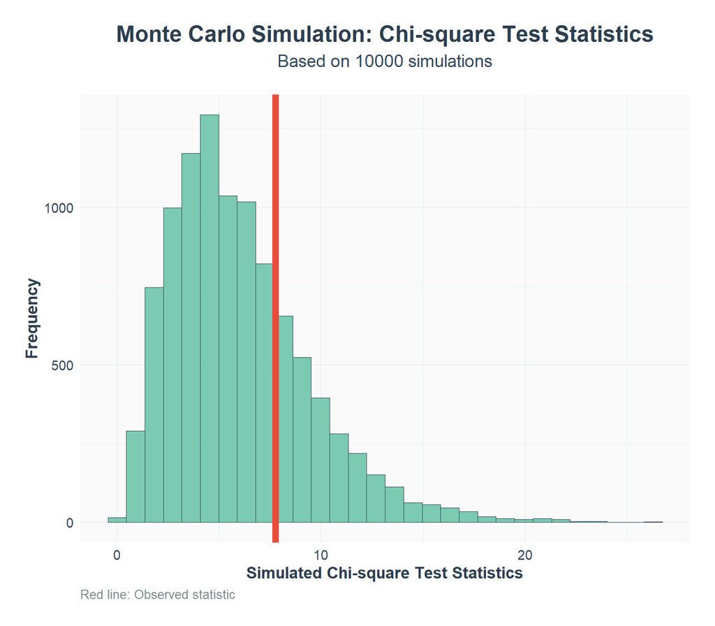

#### Test statistics

- p-value: 0.2549
- Observed test statistics: 7.770262
- degree of freedom: (r-1) x (c-1) = (3-1) x (4-1) = 2 x 3 = 6
- Number of simulation: 10000

#### Decisions

- p > 0.05
- Retain the hypothesis, after 10000 simulations, we cannot reject the null hypothesis stating that there is no association between target grade and assignment approach.

#### Test with Confidence Interval (at 95%) and Critical Value

What would be the chi-square values if we do the test again, can we predict its value, or at least know an expected value that may come off?

```r
# Calculate 95% CI for Monte Carlo p-value
alpha = 1 - 0.95
chi_sq_ci <- quantile(mc_results$simulated_chi_sq,
                       probs = c(alpha/2, 1-alpha/2))
critical_value <- quantile(mc_results$simulated_chi_sq, 0.95)
```

- Confidence Interval at 95% confidence level: CI = [1.251572, 14.314761].
- Critical value = 12.38341.
- Most of the time, under H0, chi-square would be between 1.251572 and 14.314761.
- The 95% confidence level interval for chi-square statistics under random selection is [1.251572, 14.314761], with critical value of 12.38341 at a = 0.05. Our observed chi-square statistic of 7.770262 falls within the range, so it makes sense if the above test with p-value cannot reject the null hypothesis.

#### Key findings

As we can see, the observed test statistics lie around the value of 8 which appear to be not too extreme and fit what the discovered statistics we already fail. A chi-square test of independence was conducted to examine the relationship between target grade and assignment approach. The test yielded χ² = 7.77 with df = 6, p = 0.2549. Since p > 0.05, we fail to reject the null hypothesis. There is insufficient evidence to conclude that students’ target grades are associated with their assignment approaches in this sample.”

### Research 2: Do students with higher academic aspirations (High Distinction or lower grades) spend significantly more time studying per week on average.

In this question, let’s see if students who aim for High Distinction spend significantly more hours compare to the others (first we would try to use two-samples t-test to compare the mean).

#### Hypothesis

$$\begin{align*}
&H_0: \text{ There is no difference between the means of weekly study hours of students who aim for High Distinction compare to the rest.} \\
&H_1: \text{ Student aiming for High Distinction study more on average.}
\end{align*}$$

#### Significance level

$$\alpha = 0.05$$

#### Assumptions

- Our sample population follows a normal distribution
- Study hours in both groups follows normal distribution
- The variance of study hours is equal between both groups
- Both group represents random samples from their respective populations

#### Checking assumptions

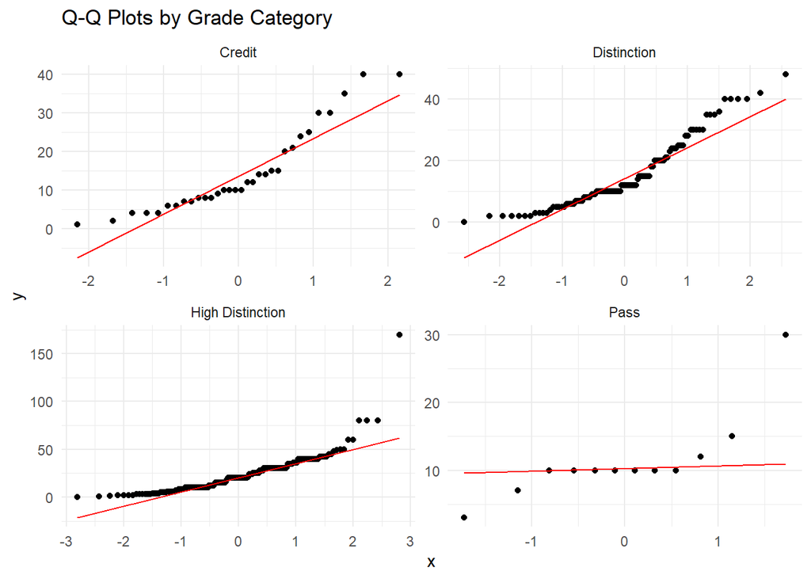

    ```r
    qq
    ```

- **Boxplot Variance Analysis:**
  - **Unequal variances** are clearly evident (different box sizes and whisker lengths)
  - High Distinction has much larger spread than others
  - Multiple outliers present, HD with significantly extreme outliers.

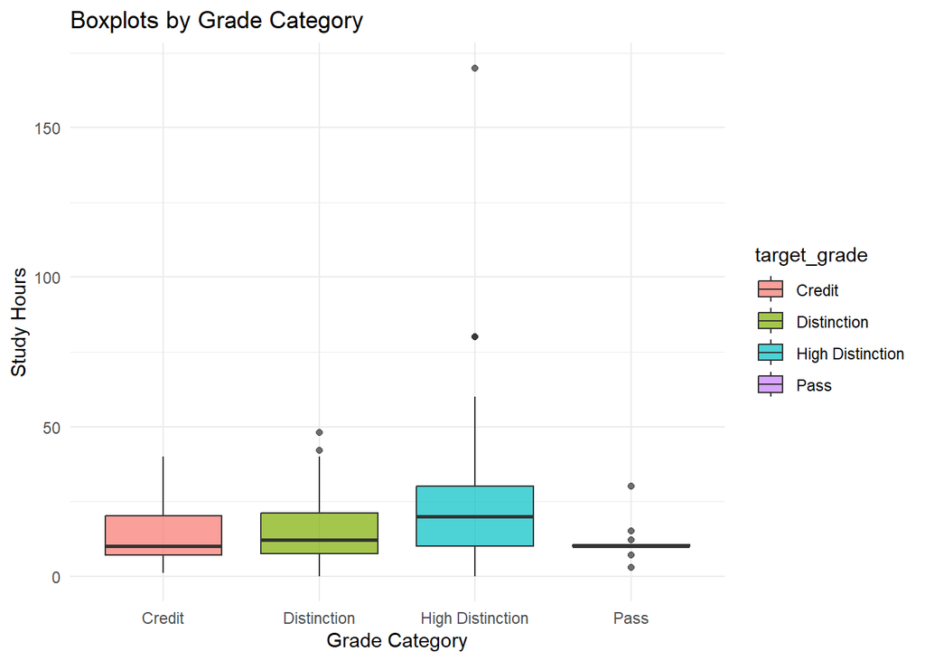

    ```r
    box
    ```

- **Density Plot Analysis:**
  - Credit: Right-skewed distribution, not bell-shaped
  - Distinction: Most normal-looking, slight right skew
  - High Distinction: Heavily right-skewed with long tail
  - Pass: Too few observations, irregular shape

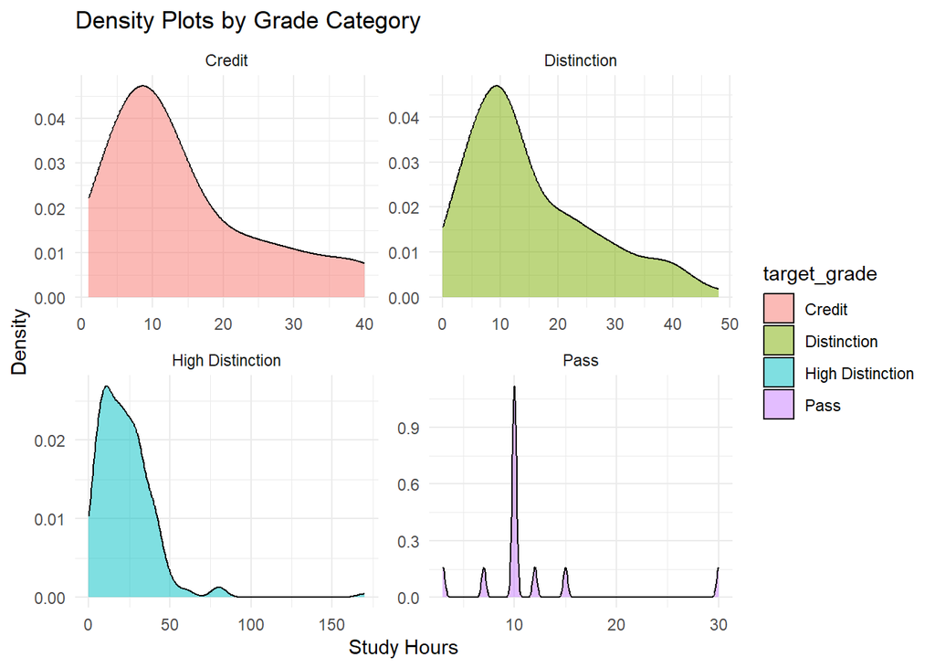

    ```r
    dense
    ```

Visualisations alone cannot help or confirm whether data is normally distributed or not, we still have to inspect by tests for normal distribution using Shapiro-Wilk test.

```r
# Function to test normality for each group
test_normality <- function(data_group, group_name) {
  sink("NUL")
  cat("\n=== Normality Tests for", group_name, "===\n")

  # Shapiro-Wilk test (best for small samples, n < 50)
  if(length(data_group) <= 5000) {
    shapiro_result <- shapiro.test(data_group)
    cat("Shapiro-Wilk Test:\n")
    cat("W =", round(shapiro_result$statistic, 4),
        ", p-value =", format(shapiro_result$p.value, scientific = TRUE), "\n")
  } else {
    cat("Shapiro-Wilk Test: Skipped (n > 5000)\n")
  }


  # Interpretation
  cat("\nInterpretation (α = 0.05):\n")
  if(exists("shapiro_result") && shapiro_result$p.value > 0.05) {
    cat("Shapiro-Wilk: Normal distribution (p > 0.05)\n")
  } else if(exists("shapiro_result")) {
    cat("Shapiro-Wilk: Non-normal distribution (p ≤ 0.05)\n")
  }
  sink()
}

# Test each group
test_normality(hd, "HD")
test_normality(p, "Pass")
test_normality(c, "Credit")
test_normality(d, "Distinction")
```

[output not shown]

- Since we know our data is created in the survey, the data is independent of each other!

### Performing Tests

```r
# Manual Mann-Whitney U Test Function
manual_mann_whitney <- function(group1, group2) {
  # Step 1: Combine data with group labels
  combined_data <- c(group1, group2)
  group_labels <- c(rep("Group1", length(group1)),
                   rep("Group2", length(group2)))

  # Step 2: Rank all combined data
  ranks <- rank(combined_data, ties.method = "average")

  # Step 3: Separate ranks by group
  ranks_group1 <- ranks[group_labels == "Group1"]
  ranks_group2 <- ranks[group_labels == "Group2"]

  # Step 4: Calculate rank sums
  R1 <- sum(ranks_group1)
  R2 <- sum(ranks_group2)

  n1 <- length(group1)
  n2 <- length(group2)
  N <- n1 + n2  # Total sample size

  # Step 5: Calculate U statistics
  expected_W <- n1 * (N + 1) / 2
  U1 <- n1 * n2 + n1 * (n1 + 1) / 2 - R1
  U2 <- n1 * n2 + n2 * (n2 + 1) / 2 - R2

  # Step 6: Test statistic (minimum U)
  U <- U1

  # Step 7: Normal approximation (for large samples)
  mu_U <- (n1 * n2) / 2
  sigma_U <- sqrt((n1 * n2 * (n1 + n2 + 1)) / 12)
  z_score <- (U - mu_U) / sigma_U

  # Step 8: P-value (two-tailed)
  p_value <- pnorm(abs(z_score), lower.tail = FALSE)

  # Return results
  list(
    U1 = U1,
    U2 = U2,
    U = U,
    z_score = z_score,
    p_value = p_value,
    n1 = n1,
    n2 = n2,
    W1 = R1,
    W2 = R2,
    ranks_group1 = ranks_group1,
    ranks_group2 = ranks_group2,
    eW = expected_W
  )
}
hd_p = manual_mann_whitney(hd, p)
hd_c = manual_mann_whitney(hd, c)
hd_d = manual_mann_whitney(hd, d)
# Example with your HD vs other groups
# Assuming you have vectors hd_data and other_data
# result <- manual_mann_whitney(hd_data, other_data)
# print(result)
```

#### Test statistics

##### High Distinction vs Distinction

##### $W_{hdd} = n_{hd} . \frac{N+1}{2} = 29750.5$

##### High Distinction vs Credit

$W_{hdc} = n_{hd} . \frac{N+1}{2} = 23084$

##### $W_{hdp} = n_{hd} . \frac{N+1}{2} = 21094$

#### Observed Test Statistic

##### High Distinction vs Distinction

- $w_{hdd} = 32502$
- **P-value:** $\text{P}(W \geq w) << 0.05$

##### High Distinction vs Credit

- $w_{hdc} = 24123$
- **P-value:** $\text{P}(W \geq w) < 0.05$

#### Decision

- Since p-value < 0.05 in all cases, there is a **strong evidence** that HD students tend to study more hours than the comparison group since we reject H0.
- Now let’s try and run the test with built-in function.

  ```r
  # Test HD vs each group separately (one-tailed tests)
  test_hd_vs_distinction <- wilcox.test(hd, d, alternative = "greater")
  test_hd_vs_credit <- wilcox.test(hd, c, alternative = "greater")
  test_hd_vs_pass <- wilcox.test(hd, p, alternative = "greater")

  # View results
  cat("HD vs D:", test_hd_vs_distinction$p.value)
  ```

  ```
  HD vs D: 4.104403e-05
  ```

  ```r
  cat("HD vs C", test_hd_vs_credit$p.value)
  ```

  ```
  HD vs C 0.001491652
  ```

  ```r
  cat("HD vs P", test_hd_vs_pass$p.value)
  ```

  ```
  HD vs P 0.004230571
  ```

The p-value seems to fit what we already done above!

#### Key findings

The analysis revealed statistically significant differences (p < 0.05) in study behavior patterns, with HD aspirers consistently demonstrating higher weekly study hours compared to all other grade categories examined.

- **Academic counseling**: Students should be informed about the study time commitment typically associated with HD-level performance
- **Expectation management**: Clear communication about the relationship between effort and achievement outcomes

### Research 3: Bathroom Stall Selection Patterns

The report has been quite dense with statistics, so let’s switch gears and add a little fun into the mix! Let’s explore a more lighthearted question: How do students in DATA2x02 choose their bathroom stalls? Are their choices systematic and consistent, or are they completely random? By examining this everyday decision-making process, we might uncover some unexpected patterns.

There’s some interesting research that suggests people tend to avoid the first stall due to a perceived lack of privacy, while others gravitate toward the middle option for a sense of security. Could these tendencies hold true for our students? By investigating their choices, we might uncover valuable insights into how people make decisions in seemingly mundane situations.

To test this, we’ll perform a Chi-square goodness-of-fit test to determine whether students’ stall selections align with random chance or follow a more structured pattern.

#### Hypothesis

$H_0: \text{ The stall preference are random, there is no bias toward any stall}$

$H_1: \text{ Data2x02 show systematic preference towards a certain stall}$

#### Significance Level

$$\alpha=0.05$$

#### Assumptions

- The populations are independent
- Expected count for each choice is not any smaller than 5 ($e_i = n p_i \geq 5$)

#### Visualisations

```r
df = tibble(
  stall_choice = c("first", "middle", "last"),
  y = c(85, 81, 199),
  p = c(1/3, 1/3, 1/3),
  e = sum(y) * p)
```

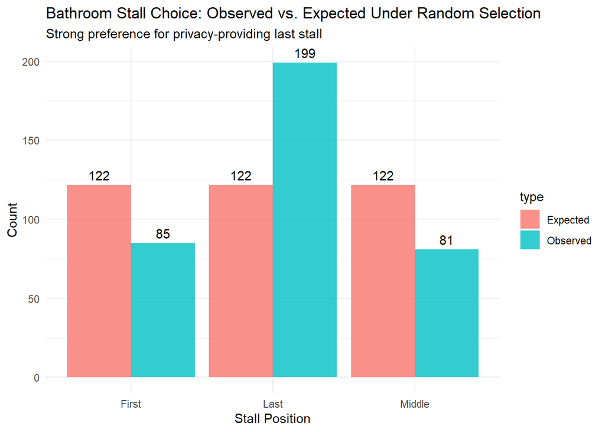

```r
df_comparison <- data.frame(
  stall = rep(c("First", "Middle", "Last"), 2),
  count = c(85, 81, 199, 121.67, 121.67, 121.67),
  type = rep(c("Observed", "Expected"), each = 3)
)

ggplot(df_comparison, aes(x = stall, y = count, fill = type)) +
  geom_col(position = "dodge", alpha = 0.8) +
  geom_text(aes(label = round(count)), position = position_dodge(width = 0.9), vjust = -0.5) +
  labs(title = "Bathroom Stall Choice: Observed vs. Expected Under Random Selection",
       subtitle = "Strong preference for privacy-providing last stall",
       x = "Stall Position", y = "Count") +
  theme_minimal()
```

First and Middle stall are less likely to be chosen but the Last one is spefically high when being visualised.

#### Checking assumptions

- Under null hypothesis, $p_{first} =p_{middle} = p_{last} = p = 1/3 \text{ => } e_{first} = e_{middle} = e_{last} = e = n.p$ .
- Since e = 121.6667, we are sure that none assumptions are violated.

#### Observed Test Statistics

```r
y = df$y
e = df$e
#Observed Test Statistic
t0 = sum((y - e)^2/e)
#p-value
pval = pchisq(t0, df = 2, lower.tail = F)
```

- **Test statistic:** $t_0 = \sum^3_{i=1} \frac{(y_i-e_i)^2}{e_i} = 73.79726$
- **Degree of freedom**: df = k - 1 - q = 3 - 1 - 0 = 2
- **P-value:** P($\chi^2_2 \geq 73.79726$) << 0.05

#### Decision

- Since p << 0.05, there is a strong evidence to reject the null hypothesis, people don’t randomly choose the stall but rather having a specific preference towards the third stall.

#### Some external studies about behaviors

In addition to our own investigation, external studies offer valuable perspectives that can deepen our understanding of student behavior. One such study by Heston (2023) delves into the psychology behind bathroom stall selection, revealing patterns that may have broader implications for how students make decisions in academic and lifestyle contexts.

Heston’s research found that people tend to choose the last stall, often due to the increased sense of privacy it provides. As Heston notes (Heston 2023):  
*“The findings in this study support the hypothesis that people seek security when choosing which bathroom stall to use. The top choice in this study, which occurred twice as often as the other two options, was the stall with a solid wall on one side and only one exposed partition. This preference makes psychological sense, as people are drawn to the stall that offers greater privacy than the others.”*

This preference for privacy and security can be linked to broader student behaviors, particularly in academic and lifestyle choices. Just as students might opt for the bathroom stall that feels most secure, they may also seek out environments that provide comfort and control over their surroundings. In academic settings, this could manifest in students preferring smaller, quieter study spaces or choosing professors who create a more personalized, supportive classroom atmosphere. In lifestyle choices, it may reflect a tendency to gravitate toward habits or routines that offer a sense of stability and reduced uncertainty, whether it’s in their social interactions, study habits, or even daily schedules.

The strong evidence for systematic spatial choices has practical implications for university facility design. Students’ clear preference for privacy-providing options suggests that learning spaces, study areas, and social environments should incorporate varied privacy levels to optimize student comfort and well-being.

## References

DATA2x02 students. 2025. “DATA2x02 Class Survey.” 2025. https://canvas.sydney.edu.au/courses/67975/files/45130664?wrap=1.

Heston, Thomas F. 2023. “Selecting the Safest Public Bathroom Stall in the Era of COVID-19.” *Journal of Clinical Medical Research* 4 (2): 1–4. https://doi.org/10.46889/JCMR/2023.4215.

Perplexity AI, Inc. 2025. “Perplexity AI.” https://www.perplexity.ai/.

W3Schools. 2025. “R Tutorial.” https://www.w3schools.com/r/.